# Tour de France Analysis

Joseph

9/16/2020

[figure not shown]

*Tadej Pogacar, on his way to winning the 2020 Tour de France*

## Background Information

As the Tour de France 2020 is currently underway, the peloton will have to ride over 3500km in a bit less than 3 weeks. While the outcome of this year’s Tour, the first one to happen in September, is quite certain, this race is usually the theatre of much suspense and drama. Every year since 1903, the Tour de France is a cycling race taking place in the summer which slowly became inherent to the french culture.

Today, any citizen will closely follow the route of the Tour and hope for it to pass by its village and get the chance to see the ‘real’ Maillot Jaune (leader of general classification). But while this race is globally known for its difficulty, let us get a closer look to its history.

```
## Rows: 104
## Columns: 12
## $ Year     <dbl> 1903, 1904, 1905, 1906, 1907, 1908, 1909, 1910, 1911, 1912, …
## $ Stages   <dbl> 6, 6, 11, 13, 14, 14, 14, 15, 15, 15, 15, 15, 15, 15, 15, 15…
## $ Started  <dbl> 60, 88, 60, 82, 93, 112, 150, 110, 84, 131, 140, 145, 69, 11…
## $ Ended    <dbl> 21, 27, 24, 14, 33, 36, 55, 41, 28, 41, 25, 54, 11, 22, 38, …
## $ Distance <dbl> 2428, 2428, 2994, 4637, 4488, 4488, 4497, 4734, 5343, 5289, …
## $ Hour     <dbl> 94, 96, 110, 189, 158, 156, 157, 162, 195, 190, 197, 200, 23…
## $ Minutes  <dbl> 33, 5, 26, 34, 45, 53, 1, 41, 37, 30, 54, 28, 7, 36, 50, 8, …
## $ Seconds  <dbl> 0, 56, 58, 0, 5, 29, 22, 30, 0, 28, 0, 48, 15, 13, 26, 6, 30…
## $ Pace     <dbl> 25.7, 25.3, 27.1, 24.5, 28.5, 28.7, 28.7, 29.1, 27.3, 27.8, …
## $ Winner   <chr> "M. Garin", "H. Cornet", "L. Trousselier", "R. Pottier", "L.…
## $ Country  <chr> "Fra", "Fra", "Fra", "Fra", "Fra", "Fra", "Lux", "Fra", "Fra…
## $ Age      <dbl> 32, 20, 24, 27, 24, 25, 22, 21, 27, 24, 23, 24, 33, 30, 33, …
```

## Tour de France Overview

#### The Tour de France travels less distance, but the pace is dramatically increasing

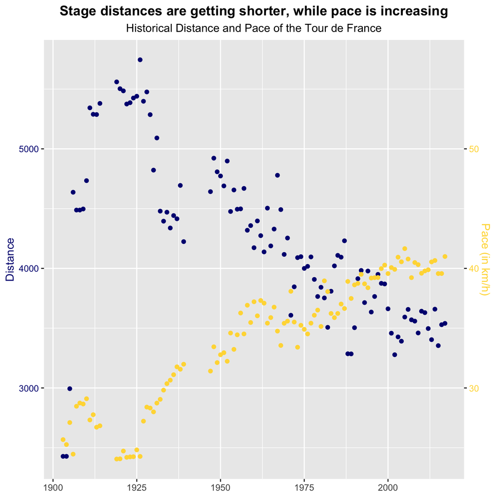

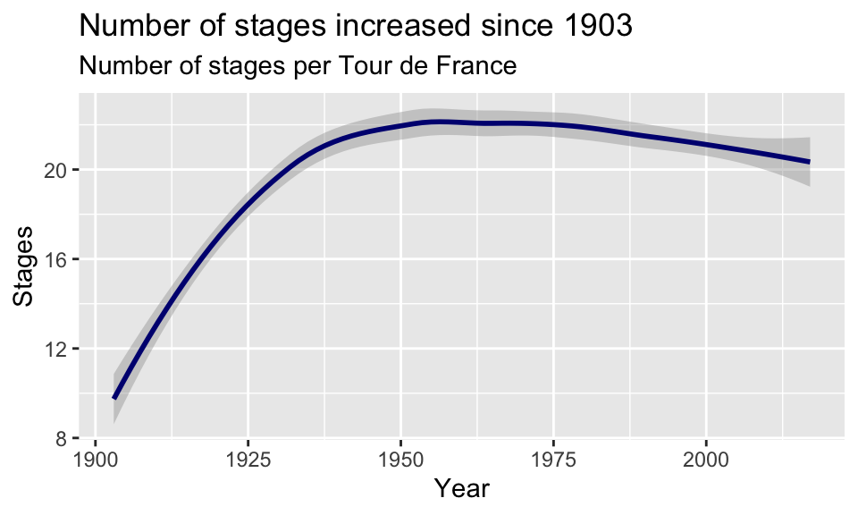

[output not shown]

```
##   Year Pace       Winner
## 1 2005 41.7 L. Armstrong
## 2 2017 41.0    C. Froome
## 3 2003 40.9 L. Armstrong
```

```
##   Year Pace    Winner
## 1 1919 24.1 F. Lambot
## 2 1920 24.1   P. Thys
## 3 1922 24.2 F. Lambot
```

```
##   Year Distance
## 1 1926     5745
## 2 1919     5560
## 3 1920     5503
```

```
##   Year Distance
## 1 1903     2428
## 2 1904     2428
## 3 1905     2994
```

```
##   Year Distance
## 1 2002     3278
## 2 1989     3285
## 3 1988     3286
```

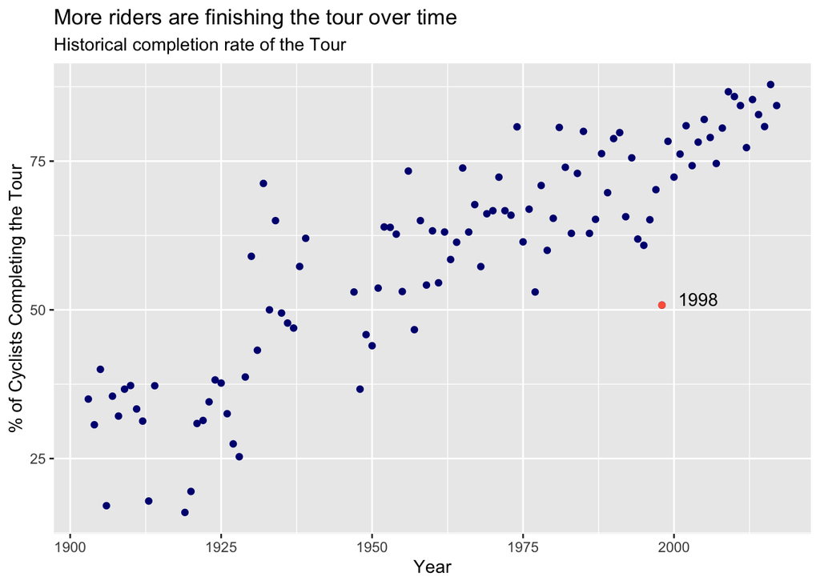

[output not shown]

The first years of the Tour de France were the theatre of an incredible spectacle between riders who would cycle night and day to join two cities. The lack of preparation and equipment led to many retirements and abandons. At the time, there were quite many disqualification as many occurrences of cheating, such as taking the train or a car to shorten the distance, were reported. However, drinking wine to boost your performance was not illegal!  
In the more recent era of cycling, the falls and crashes are the most common reason for abandons. Another reason explaining disqualifications are the maximum delay rules, which entails that participants must finish the stage under a certain time, a rule which can be difficult for some riders in the mountain stages.  
Note that the 1998 Tour de France saw the abandon of many cycling teams participating to the Tour due to the “Festina Scandal”, one of the first doping scandals of the sport.  
#### France is the counts the most wins

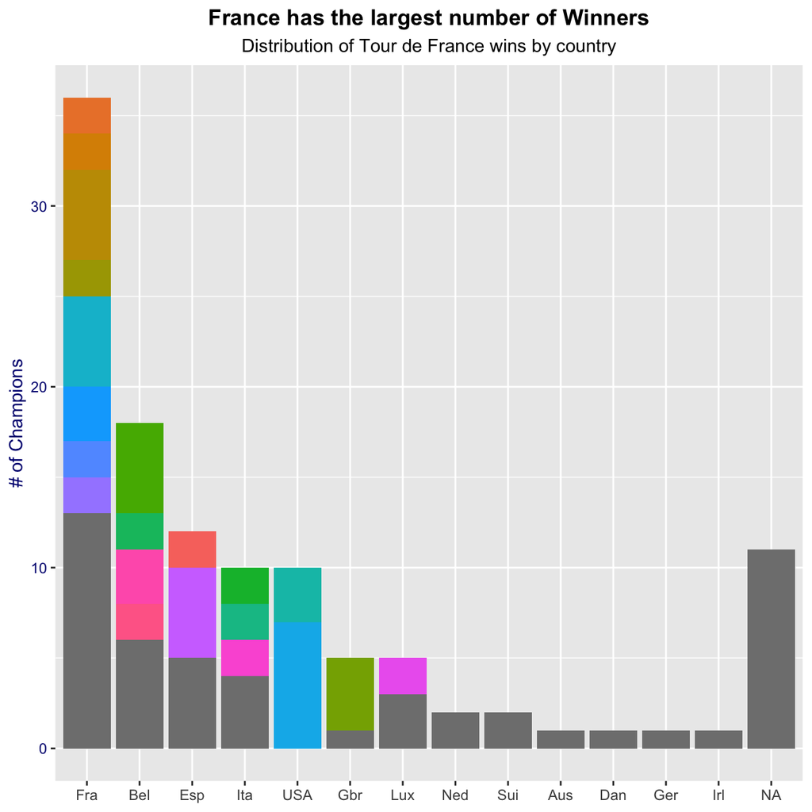

Let us now analyse the victories of the Tour de France, the most prestigious cycling race in the world. With regards to nationality, France counts the most champions with 36 victories. Note however that the last French winner of the tour de France Bernard Hinault was in 1985… Belgium comes second with 18 victories while the Spain is third (12 victories).

```
## # A tibble: 21 x 2
##    Winner       Count
##    <chr>        <int>
##  1 L. Armstrong     7
##  2 B. Hinault       5
##  3 E. Merckx        5
##  4 J. Anquetil      5
##  5 M. Indurain      5
##  6 C. Froome        4
##  7 G. LeMond        3
##  8 L. Bobet         3
##  9 P. Thys          3
## 10 A. Contador      2
## # … with 11 more rows
```

With regards to individual winners of the Tour de France, the rider with the most victories is Lance Armstrong, which was however convicted of doping a few years and saw all his wins cancelled. 4 riders have won the Tour 5 times, and Christopher Froome who won it 4 times already will try to join them in the classification in the Tour 2021. In total, 21 riders won the Tour at least 2 times.

### Tour de France By Stages

The overall Tour de France is won by the cyclist that has the fastest culmulative time. However, there the fastest rider of each stage is still wildly celebrated and their wins contribute to the points classification as well as the team classification. Here, we take a closer look at the Tour de France Stage Winners.

#### Stage Wins Ranking Differ from Tour Wins Ranking

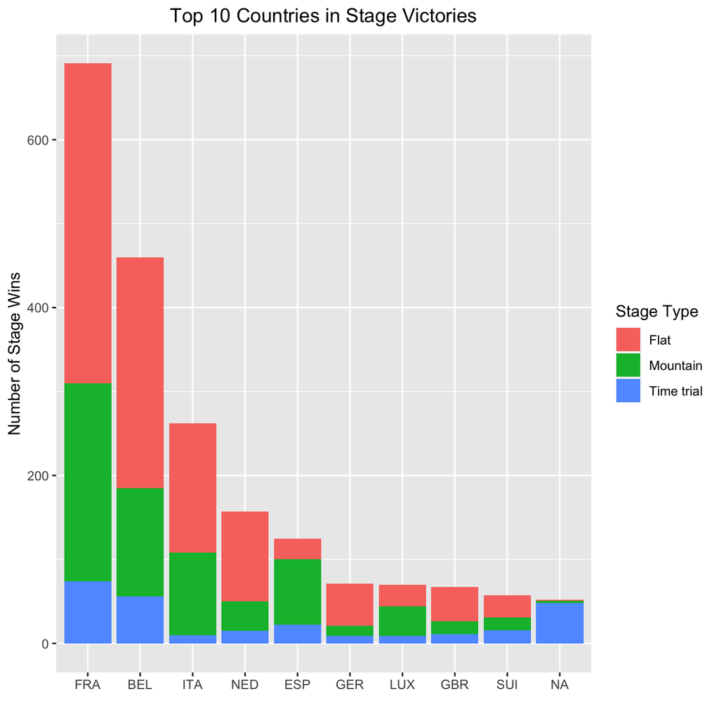

Once again, France has is the most decorated country in terms of stage wins with Belgium in second place. While Spain came in third in terms of Tour wins, it was fifth in terms of Stage wins. The Netherlands, which had won 2 Tours total, had won 157 Stages. On the other hand, if we still count the 7 Tour titles by Lance Armstrong, the USA had won 10 Tours while only winning 38 Stages. Winning more stages certainly makes it more likely to win the Tour, it seems that there is some wiggle room in the absolute rankings.

We also note that an unusually large portion of Spain’s victories come from Mountain Stages. Perhaps there’s something about Spanish racers make them particularly formidable opponents on climbs?

#### ~130 Cyclists are Responsible for Over Half of All Stage Victories

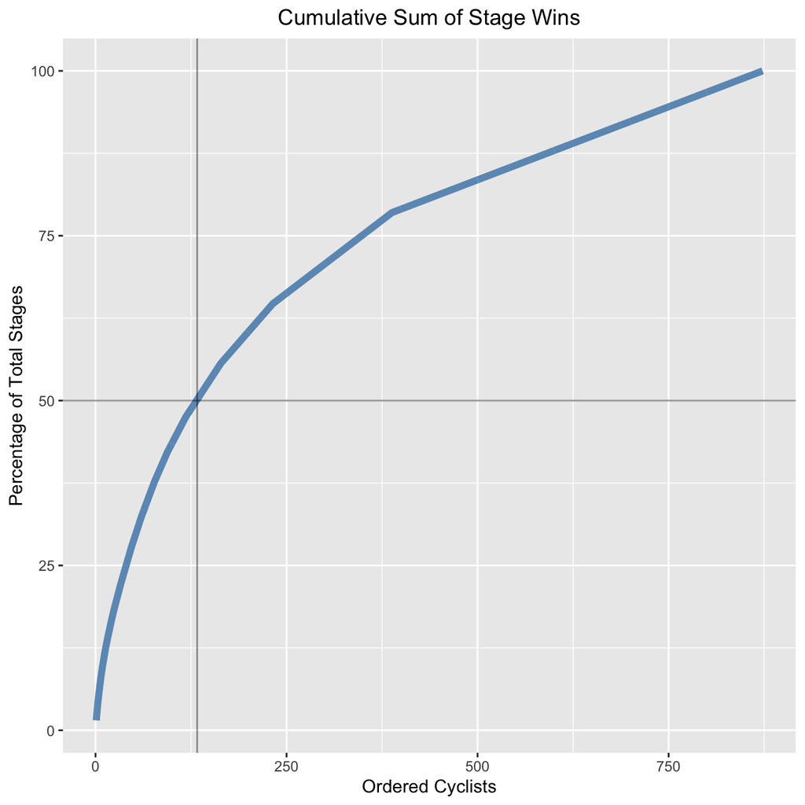

When we plot the cumulative sum of the stage wins, we can see that around 130 cyclists can account for more than 50% of all the stages won during the Tour de France. Furthermore, we see that riders who have won a single stage only account for less than 25% of all stages.

Now, let’s hone in on the most decorated riders.

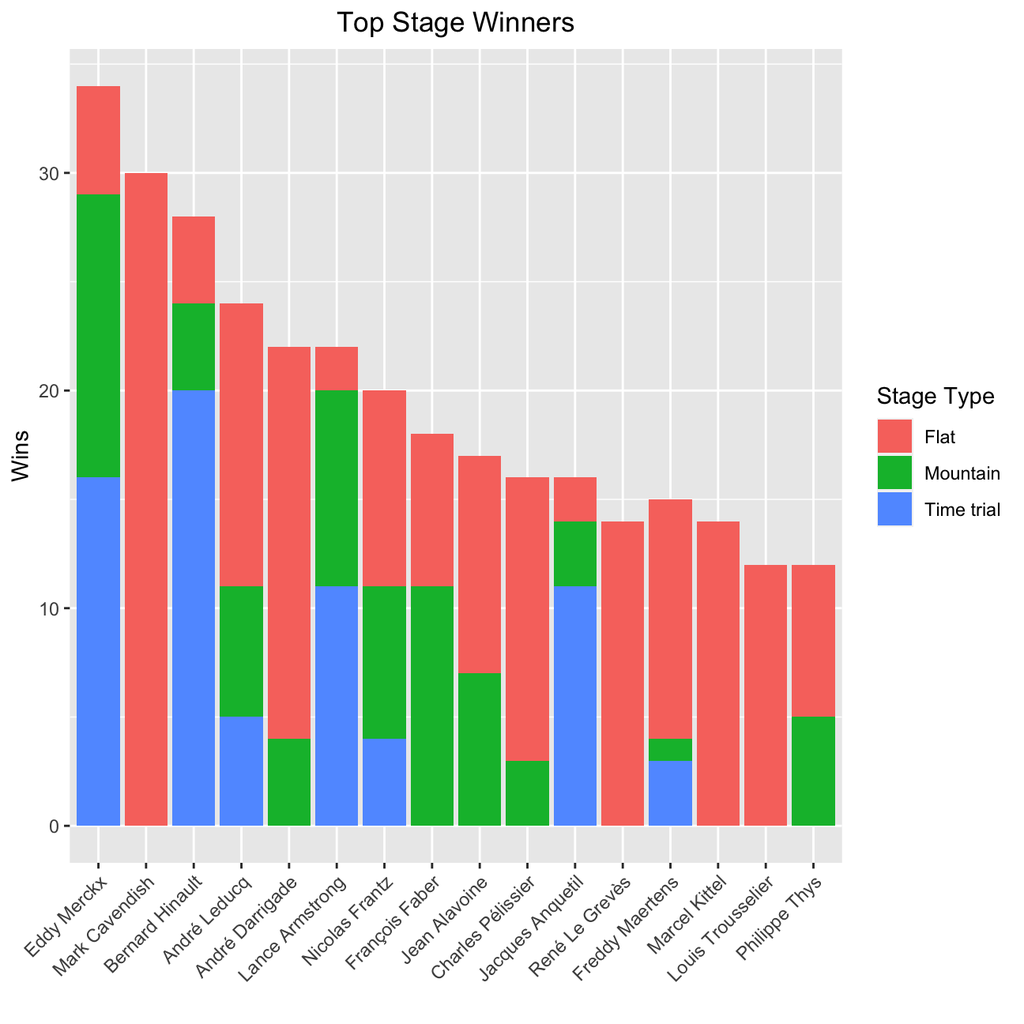

Eddy Merckx is the most decorated rider with a whopping total of 34 stage wins. Furthermore, we notice that the majority of riders specialize in only two, if not one, of the three different stage categories. However, Eddy managed to win stages of all types. Other well-rounded cyclests include Bernard Hinault, André Leducq, Lance Armstrong, Nicolas Frantz, Jacques Anquetil, and Freddy Maertens. With the exception of Maertens, the remaining other all-rounder cyclists have all won the Tour de France during their career. Perhaps that is an indication that in order to win the Tour, one has to be outstanding across a variety of terrains.

**Records**  
Most Flat Stage Wins: *Mark Cavendish*  
Most Mountain Stage Wins: *Eddy Merckx*  
Most Time Trial Stage Wins: *Bernard Hinault*

#### Stage Distances Have Also Shortened Over the Years

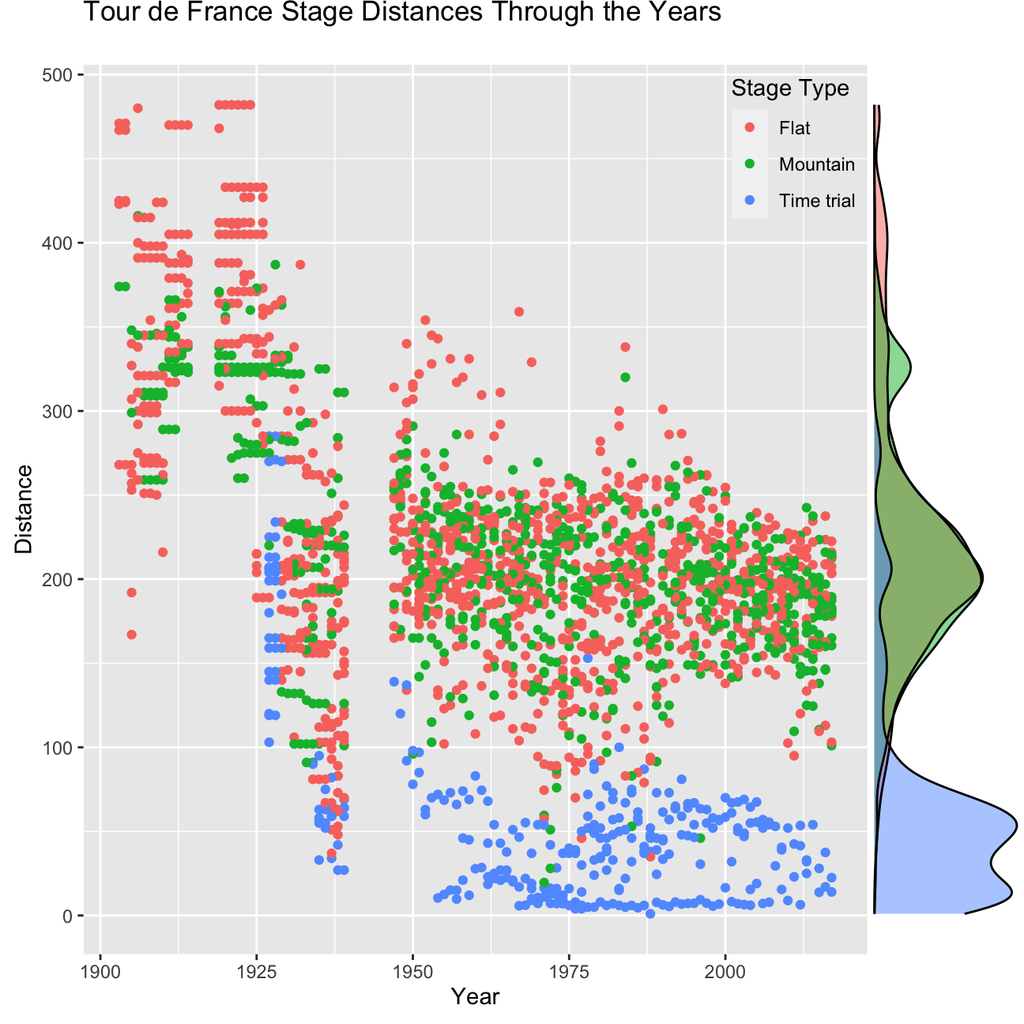

We already knew that over the years, the total distance covered in the Tour de France has decreased. But what about on the individual stage level? Have stage distances decreased as well? It turns out, yes, they have. Every single stage type has decreased in length since the beginning of the Tour de France.

From the density plot on the right, we can see that generally, Time Trial Stages are the shortest, while Flat and Mountain Stages are comparable in length. We see that there is a small bump representing very long Mountain Stages that appears like an outlier. Upon closer inspection, we realize that long Mountain Stages are a relic of the past, occuring nearly exclusively before ~1930. During this time period, Time Trials were also much longer than modern day Trials.

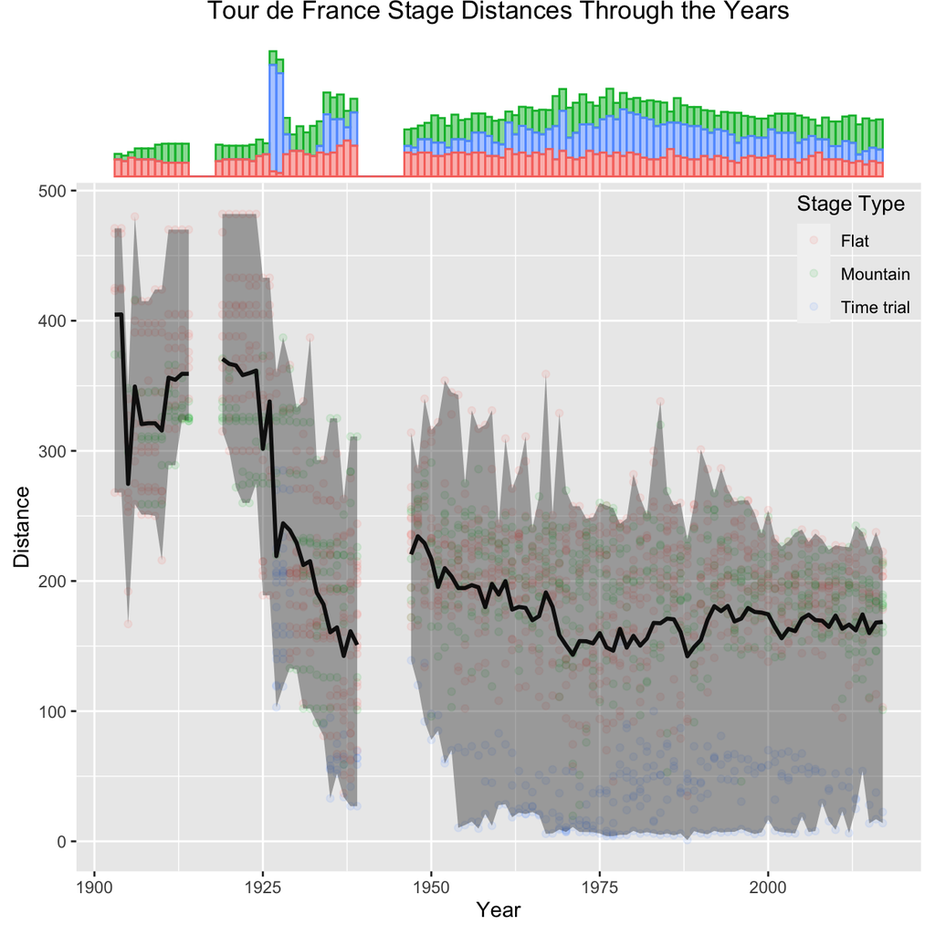

We can also look at the distribution of stage types across the years. We see that when the Tour first began, there were very few stages, each being incredibly long. We also notice that Time Trial Stages were not actually introduced until 1927, when they became the most common stage. This persisted for one more year before they once again became the rarest stage. In recent years, the Tour de France has consisted of 21 stages. The average stage length (denoted by the black line) as well as minimum and maximum stage length (denoted by the grey ribbon) has been consistent as well.

### Conclusion and Next Steps

It’s so interesting to see historial events emerge as outliers from this whirlwind tour of the history of the Tour de France. From identifying winners to looking at distance and stage trends, we can see that the Tour de France today is a very different race from the one that was started in 1903.

In the future, I would love to look in more detail about each individual cyclist’s performance and look for trends through the years. From what I understand, this data can be scraped from the [Official Tour de France website](https://www.letour.fr/en/history). This has been done by Thomas Camminady as stated on his [website](https://www.camminady.org/every-cyclist-of-the-tour-de-france-in-a-single-csv-file/). When I get a chance, I would love to do some exploratory data analysis on this dataset.

### Final Note

I was inspired to work on a Tour de France dataset thanks to the documentary “**Eat, Race, Win**”. As someone very new to the sport of cycling, the Tour de France, I am sure there are mistakes in my interpretations. Any advice, suggestions, or corrections are welcomed!

**Sources:**  
[Wikipedia](https://en.wikipedia.org/wiki/Tour_de_France)  
[Le Tour de France Official Website](https://www.letour.fr/en/history)  
[Stage Details Dataset](https://www.kaggle.com/ralle360/historic-tour-de-france-dataset) by RasmusFiskerBang on Kaggle